```
##         x1        x2       c1         c2           y1
## 1 1.062117  4.456910 2.815772 -8.6480303   -3.2622874
## 2 2.304469  6.832480 3.899240 -0.4981773    0.5905341
## 3 3.161286 10.844951 4.731502  1.5826061 -138.4961900
## 4 2.133296 12.299805 1.103860 -3.6676490   -1.6431834
## 5 1.655520 11.004847 2.327746 -6.9973264  -13.5417570
## 6 2.684436  8.455216 3.451417  0.3322582   86.6590810
```

4. Rode quatro modelos introduzindo uma variável dependente por vez – primeiro x1, depois x2 - e depois as dependentes juntas x1 e x2, depois x1, x2 e c1 apenas. O que acontece com os coeficientes destas variáveis entre os modelos? Discuta;

```
## # A tibble: 2 × 5
##   term        estimate std.error statistic p.value
##   <chr>          <dbl>     <dbl>     <dbl>   <dbl>
## 1 (Intercept)    -11.1      8.32     -1.33 0.183
## 2 x1              12.3      4.04      3.04 0.00242
```

```
## # A tibble: 2 × 5
##   term        estimate std.error statistic     p.value
##   <chr>          <dbl>     <dbl>     <dbl>       <dbl>
## 1 (Intercept)    42.4       8.31      5.11 0.000000392
## 2 x2             -3.62      1.01     -3.59 0.000341
```

```
## # A tibble: 3 × 5
##   term        estimate std.error statistic  p.value
##   <chr>          <dbl>     <dbl>     <dbl>    <dbl>
## 1 (Intercept)    17.9      11.5       1.55 0.121
## 2 x1             12.3       4.01      3.06 0.00228
## 3 x2             -3.62      1.00     -3.61 0.000322
```

```
## # A tibble: 4 × 5
##   term        estimate std.error statistic  p.value
##   <chr>          <dbl>     <dbl>     <dbl>    <dbl>
## 1 (Intercept)    12.8      11.7       1.10 0.273
## 2 x1              8.25      4.37      1.89 0.0595
## 3 x2             -3.87      1.01     -3.85 0.000128
## 4 c1              5.03      2.20      2.29 0.0223
```

```r
stargazer(modelo01, modelo02, modelo03, modelo04,
          type = "html",
          digits =  2)
```

|  | *Dependent variable:* |  |  |  |
| --- | --- | --- | --- | --- |
|  | y1 |  |  |  |
|  | (1) | (2) | (3) | (4) |
| x1 | 12.27*** |  | 12.27*** | 8.25* |
|  | (4.04) |  | (4.01) | (4.37) |
| x2 |  | -3.62*** | -3.62*** | -3.87*** |
|  |  | (1.01) | (1.00) | (1.01) |
| c1 |  |  |  | 5.03** |
|  |  |  |  | (2.20) |
| Constant | -11.09 | 42.42*** | 17.87 | 12.84 |
|  | (8.32) | (8.31) | (11.52) | (11.71) |
| Observations | 1,000 | 1,000 | 1,000 | 1,000 |
| R<sup>2</sup> | 0.01 | 0.01 | 0.02 | 0.03 |
| Adjusted R<sup>2</sup> | 0.01 | 0.01 | 0.02 | 0.02 |
| Residual Std. Error | 63.79 (df = 998) | 63.67 (df = 998) | 63.41 (df = 997) | 63.27 (df = 996) |
| F Statistic | 9.25*** (df = 1; 998) | 12.92*** (df = 1; 998) | 11.19*** (df = 2; 997) | 9.24*** (df = 3; 996) |
| *Note:* | p<0.1; p<0.05; p<0.01 |  |  |  |

Com a introdução das variáveis X2. c1 e c2. a variável x1 diminui em significância estatística, mas a x2 mantém coeficiente próximo e mantém significancia estatística.

- o coeficiente pode ser significativo mas ter um valor muito pequeno, pois temos que considerar a unidade em que está o coeficiente.
- o esperado, ao introduzir novas variáveis explicativas e novos controles, é que mantenham a significância.
- quando se introduz variáveis e nenhuma explica, podem ser outros problemas.
- Um R2 alto e nenhuma variável explicativa = problema.
- Um resultado desse tipo aponta para multicolineariedade.
- Uma das formas de se detectar multicolineariedade é essa: introduzir variáveis uma por vez e vendo o que acontece na introdução de cada uma.

## Multicolineariedade:

O problema de multicolineariedade surge no processo de inversão da matriz (ver fórmula de beta). Quando há colineariedade perfeita, a matriz não é inversível. Se uma variável tem alguma colineariedade, ou seja, está perfeitamente ou algo relacionado com outra, existe associação entre as variáveis e haverá problemas no seu modelo. Quando há uma variável vinculada à combinação das outras, a matriz inversa existirá, o beta será estimável, mas dificultará que haja significância estatística no seu modelo.

Uma das formas de identificar isso é ver matriz de correlação entre as variáveis: se há variáveis com correlação muito próximas de 1, muito provavelmente haverá problema de multicolineariedade. Porém, se o problema de multicolineariedade for entre uma variável e a combinação entre outras, a matriz de correlação não será o suficiente para mostrar.

Preocupação maior com a explicação substantiva do que significam os coeficientes, e menos importância para p-valor e multicolineariedade. A multicolineariedade não viesa a estimativa do ponto, a multicolineariedade não interfere na estimativa do beta, a multicolinearidade influencia num erro padrão mais “inflado” do que deveria estar.

A multicolineariedade está interferindo na soma dos resíduos (R2) e o erro padrão, atrapalhando também intervalo de confiança e p-valor. Mas não interferindo nas médias, isto é, nos betas.

A matriz de correlação não mostrará, por exemplo, se x1 é multicolinear com x2 e x3 juntos, só vai mostrar sua correlação com x2 OU com x3. Então o problema é descobrir qual variável está produzindo a multicolineariedade.

Variance Inflation Factor (VIF) = forma de encontrar multicolineariedade. Se o R2 for perto de 0, o VIF será perto de 1. Se o R2 está perto de 1, o VIF tenderá ao infinito.

Também podemos descobrir multicolineariedade rodando modelos em que as variáveis X em função das outras variáveis e controles. Se houver baixa significância, o modelo consegue mostrar se há multicolinearieade medindo uma variável em presença das outras.

5. Agora rode um quinto modelo completo com as duas variáveis explicativas e as duas variáveis de controle. O que acontece com os coeficientes agora? Você detecta alguma alteração importante? Quais seriam os motivos?

```r
modelo05 %>%
  summary()
```

```
##
## Call:
## lm(formula = y1 ~ x1 + x2 + c1 + c2, data = .)
##
## Residuals:
##      Min       1Q   Median       3Q      Max
## -228.890  -38.619   -0.032   39.194  202.508
##
## Coefficients:
##             Estimate Std. Error t value Pr(>|t|)
## (Intercept)   36.456     27.946   1.305   0.1924
## x1            -4.461     14.342  -0.311   0.7558
## x2            -2.934      1.425  -2.058   0.0398 *
## c1             6.064      2.462   2.462   0.0140 *
## c2             2.201      2.365   0.931   0.3523
## ---
## Signif. codes:  0 '***' 0.001 '**' 0.01 '*' 0.05 '.' 0.1 ' ' 1
##
## Residual standard error: 63.28 on 995 degrees of freedom
## Multiple R-squared:  0.02793,    Adjusted R-squared:  0.02402
## F-statistic: 7.146 on 4 and 995 DF,  p-value: 1.131e-05
```

```r
confint(modelo05)
```

```
##                  2.5 %     97.5 %
## (Intercept) -18.383290 91.2952153
## x1          -32.604306 23.6828985
## x2           -5.730389 -0.1366245
## c1            1.231599 10.8961518
## c2           -2.439736  6.8413660
```

```r
stargazer(modelo01, modelo02, modelo03, modelo04, modelo05,
          type = "html",
          digits = 3)
```

|  | *Dependent variable:* |  |  |  |  |
| --- | --- | --- | --- | --- | --- |
|  | y1 |  |  |  |  |
|  | (1) | (2) | (3) | (4) | (5) |
| x1 | 12.275*** |  | 12.275*** | 8.251* | -4.461 |
|  | (4.036) |  | (4.012) | (4.373) | (14.342) |
| x2 |  | -3.621*** | -3.621*** | -3.872*** | -2.934** |
|  |  | (1.007) | (1.003) | (1.007) | (1.425) |
| c1 |  |  |  | 5.030** | 6.064** |
|  |  |  |  | (2.197) | (2.462) |
| c2 |  |  |  |  | 2.201 |
|  |  |  |  |  | (2.365) |
| Constant | -11.095 | 42.420*** | 17.871 | 12.841 | 36.456 |
|  | (8.321) | (8.306) | (11.524) | (11.708) | (27.946) |
| Observations | 1,000 | 1,000 | 1,000 | 1,000 | 1,000 |
| R<sup>2</sup> | 0.009 | 0.013 | 0.022 | 0.027 | 0.028 |
| Adjusted R<sup>2</sup> | 0.008 | 0.012 | 0.020 | 0.024 | 0.024 |
| Residual Std. Error | 63.790 (df = 998) | 63.674 (df = 998) | 63.409 (df = 997) | 63.275 (df = 996) | 63.279 (df = 995) |
| F Statistic | 9.248*** (df = 1; 998) | 12.921*** (df = 1; 998) | 11.194*** (df = 2; 997) | 9.241*** (df = 3; 996) | 7.146*** (df = 4; 995) |
| *Note:* | p<0.1; p<0.05; p<0.01 |  |  |  |  |

A variável x1 agora não tem mais significância estatística e diminuiu muito em significância, mudou de sinal, e x2 perdeu um pouco de significância. Porém, olhando o intervalo de confiança, não dá para dizer que o coeficiente de x1 no modelo 03 e modelo 04 são diferentes, nem o x2.

Com o modelo 05, x1 troca de sinal e perde a capacidade de explicar, e o intervalo de confiança aumenta muito pois o erro-padrão vai de 4.3 para 14.3.

Porém c2 na presença de x1 também não explica, “não roubou efeito” de x1.

6. Procure na lista de comandos do R para a aula de hoje um que permita checar se a suposta causa do comportamento observado considerado no item anterior.

Com essa informação, podemos contruir um gráfico para analisar nossos resíduos em comparação aos valores previstos pelo modelo usando o ggplot.

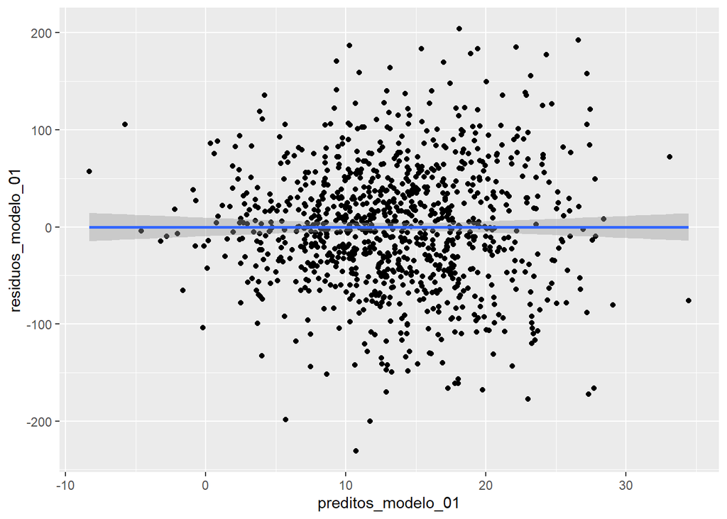

```r
ggplot(residuos_fitted_modelo01, aes(x = preditos_modelo_01, y = residuos_modelo_01)) +
  geom_point() +
  stat_smooth(method='lm')
```

Há um outro teste necessário a ser feito com o intuito de se certificar de que não há violação às hipóteses básicas do modelo MQO.

7. Rode um modelo multivariado Y = f (X2, C1, C2), primeiro apenas com a única variável explicativa x2 e depois, incluindo os controles. Escreva a nova equação estimada;

```r
summary(modelo_06)
```

```
##
## Call:
## lm(formula = y1 ~ x2 + c1 + c2, data = .)
##
## Residuals:
##      Min       1Q   Median       3Q      Max
## -228.462  -38.294   -0.135   39.158  202.580
##
## Coefficients:
##             Estimate Std. Error t value Pr(>|t|)
## (Intercept)  28.3280     9.8975   2.862  0.00430 **
## x2           -3.2281     1.0646  -3.032  0.00249 **
## c1            5.6509     2.0730   2.726  0.00652 **
## c2            1.5003     0.7207   2.082  0.03763 *
## ---
## Signif. codes:  0 '***' 0.001 '**' 0.01 '*' 0.05 '.' 0.1 ' ' 1
##
## Residual standard error: 63.25 on 996 degrees of freedom
## Multiple R-squared:  0.02783,    Adjusted R-squared:  0.0249
## F-statistic: 9.505 on 3 and 996 DF,  p-value: 3.415e-06
```

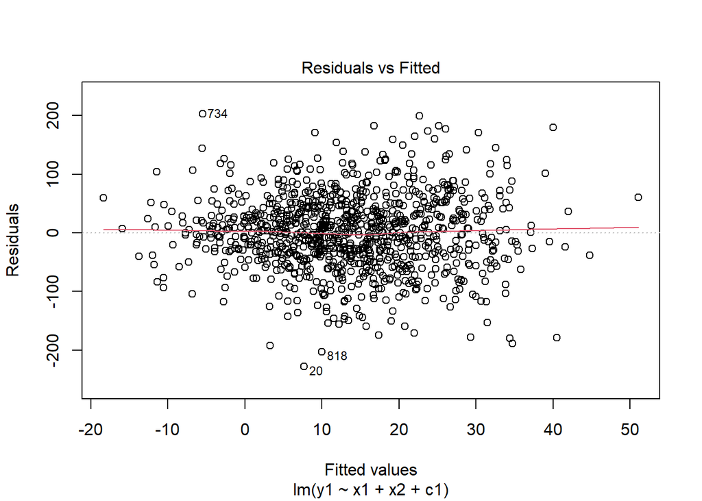

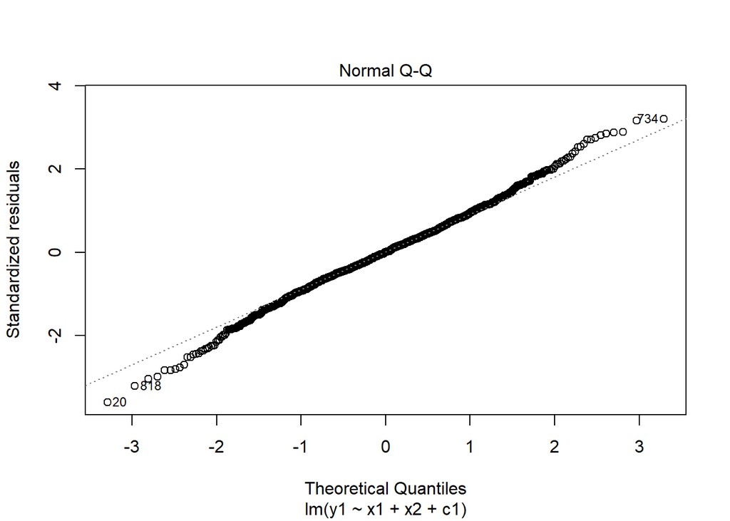

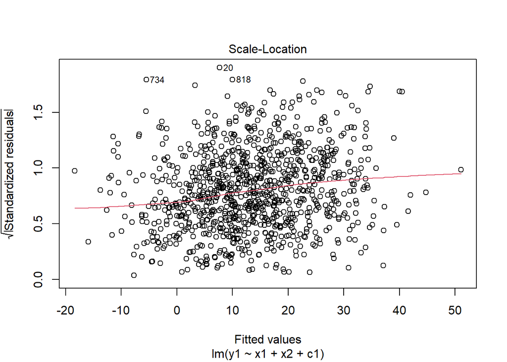

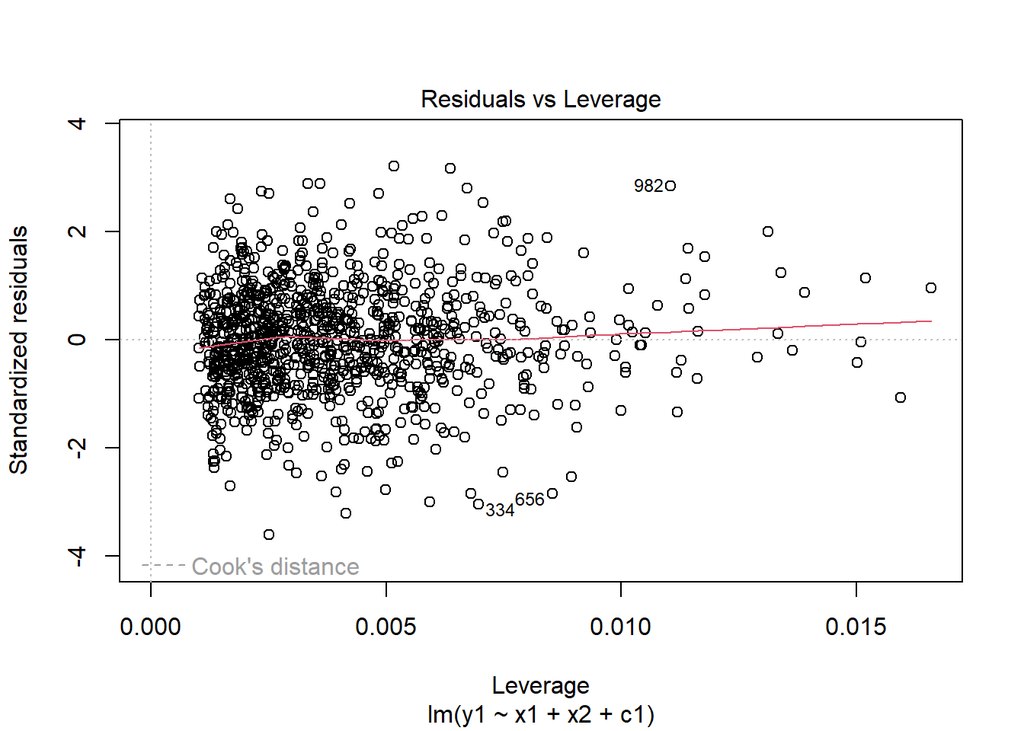

```r
plot(modelo04)
```

8. Construa um gráfico de dispersão que relacione a variável explicativa com os resíduos. O que é possível notar neste gráfico a respeito da relação entre ambas as variáveis?

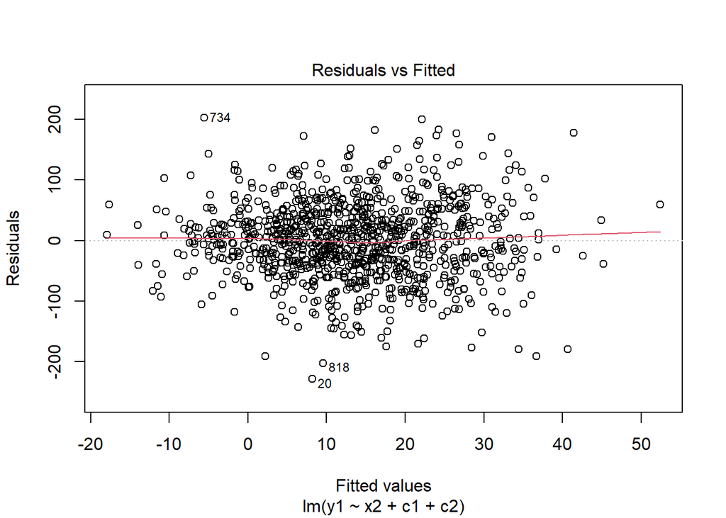

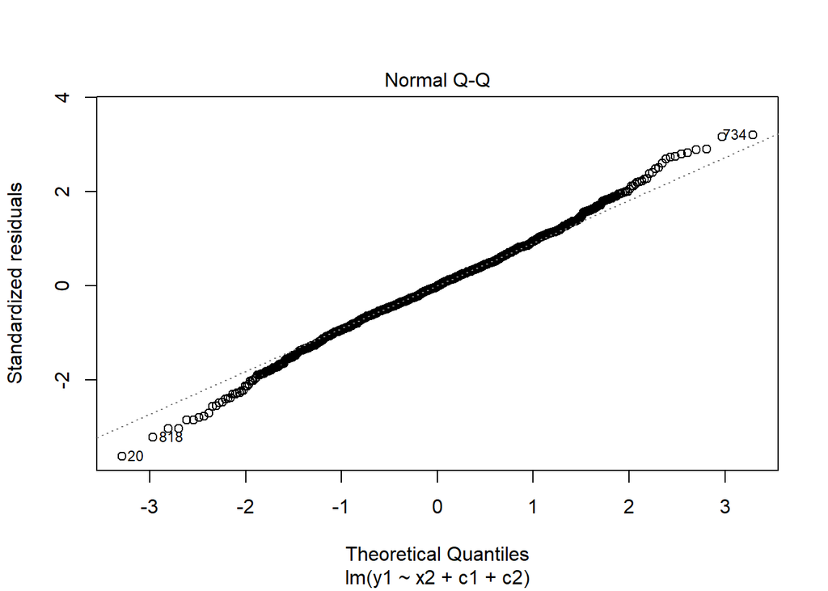

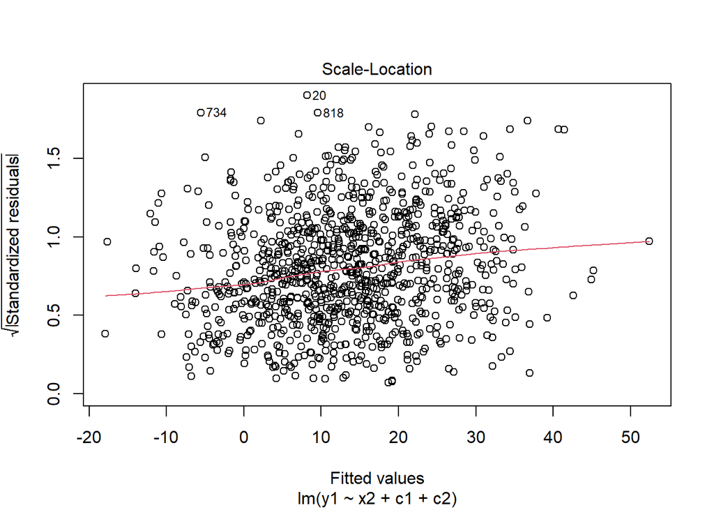

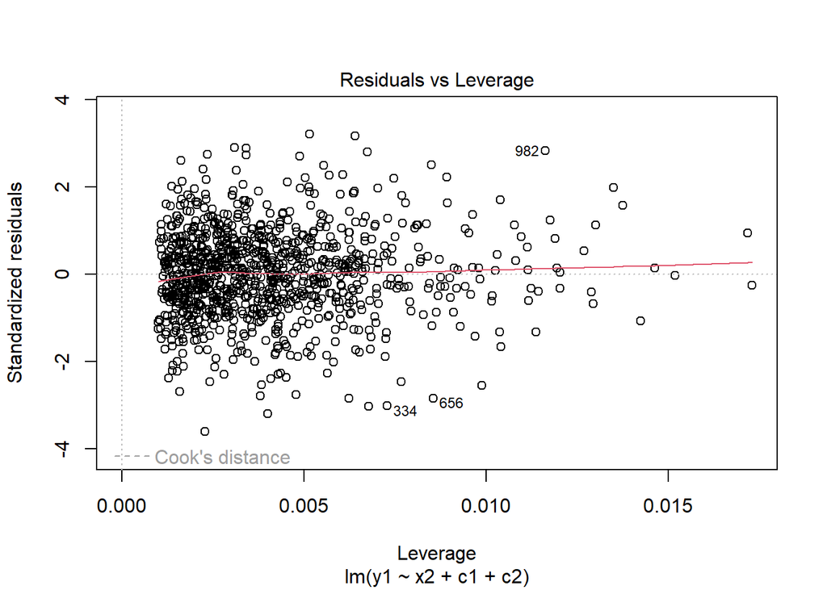

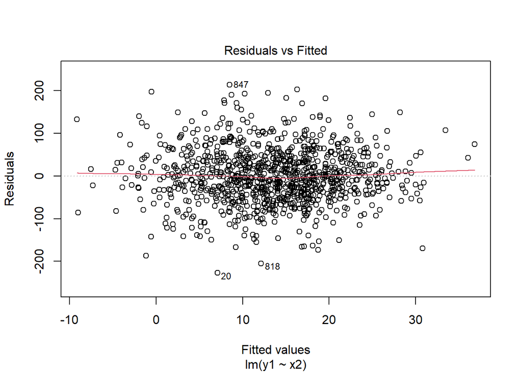

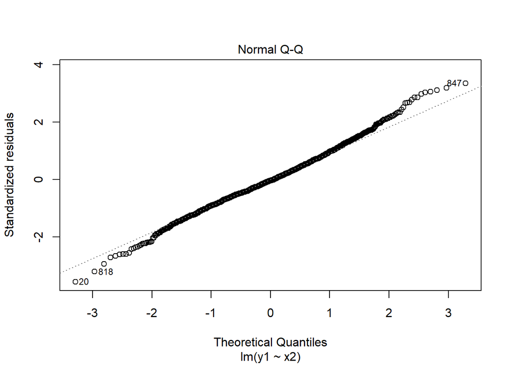

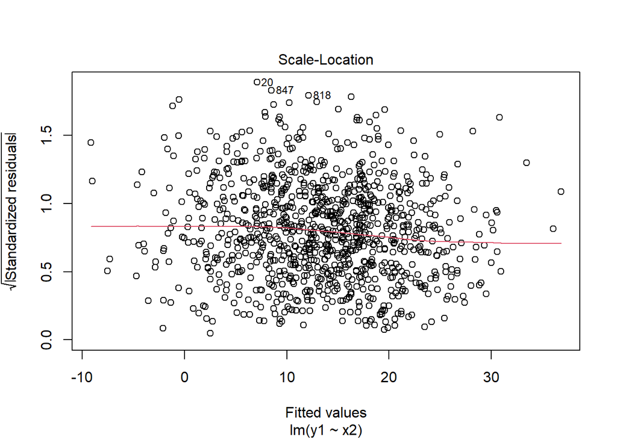

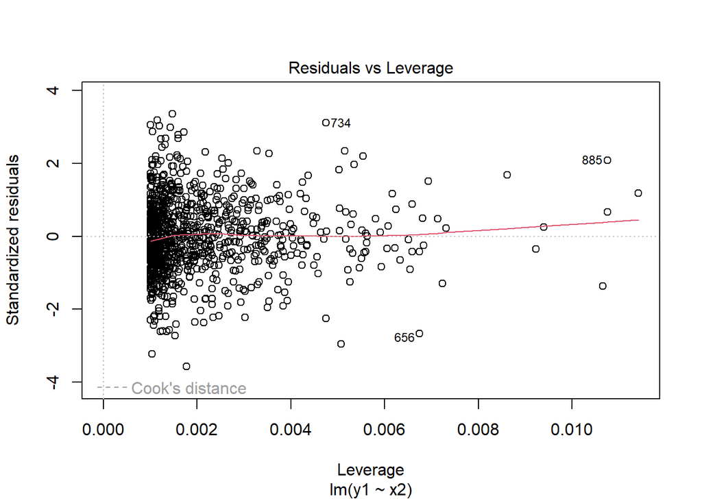

9. Encontre um outro teste entre os comandos para a aula de hoje que permita testar se esta outra hipótese foi ou não violada. Reporte os resultados. Qual sua conclusão?

Podemos fazer teste de intervalo de confiança.

Para verificar a matriz de correlação entre as variáveis de uma tabela, usamos:

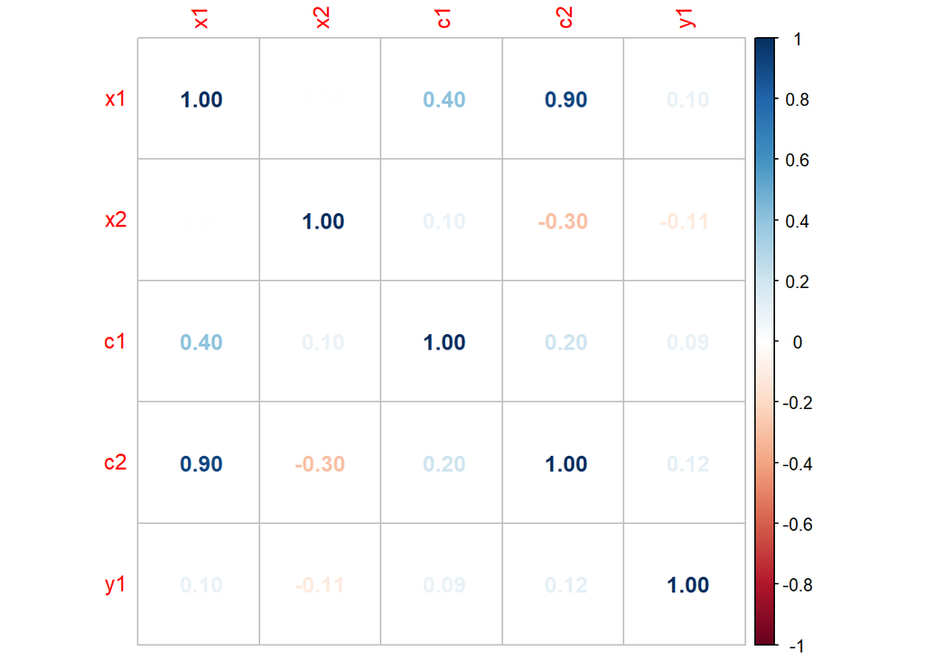

Na matriz de correlação entre as variáveis do banco, temos que x1 e c2 tem 0,9 de correlação, o que causará problema de multicolineariedade no modelo

A função bptest do pacote lmplot nos ajuda a verificar a heterocedasticidade do modelo:

```r
#bptest(reg)
#reg2 <- mtcars %>% lm(mpg ~., data=.)
#ols_vif_tol(reg2)
```

Nesta função, aplica-se um teste de hipótese no qual a hipótese nula corresponde aos resíduos estarem distribuídos com variância igual, e a hipótese alternativa aos resíduos estarem distribuídos com variância desigual.

Por fim, para testar a multicolinearidade entre os dados disponíveis, podemos usar a função ols_vif_tol do pacote olsrr.

```r
ols_vif_tol(modelo05)
```

```
##   Variables  Tolerance       VIF
## 1        x1 0.07794811 12.829047
## 2        x2 0.49328359  2.027231
## 3        c1 0.66100000  1.512859
## 4        c2 0.07963855 12.556732
```

Com o VIF de 12,8 , temos que x1 e c2 são altamente correlacionadas.

O VIF quanto menor melhor, não há um valor de corte

```r
ols_vif_tol(modelo04)
```

```
##   Variables Tolerance      VIF
## 1        x1 0.8383838 1.192771
## 2        x2 0.9880952 1.012048
## 3        c1 0.8300000 1.204819
```

```r
dados %>%
lm(x1 ~ c2, data = .) %>%
  summary()
```

```
##
## Call:
## lm(formula = x1 ~ c2, data = .)
##
## Residuals:
##      Min       1Q   Median       3Q      Max
## -0.62800 -0.14935 -0.00268  0.14955  0.69032
##
## Coefficients:
##             Estimate Std. Error t value Pr(>|t|)
## (Intercept)   2.6000     0.0115  226.16   <2e-16 ***
## c2            0.1500     0.0023   65.23   <2e-16 ***
## ---
## Signif. codes:  0 '***' 0.001 '**' 0.01 '*' 0.05 '.' 0.1 ' ' 1
##
## Residual standard error: 0.2181 on 998 degrees of freedom
## Multiple R-squared:   0.81,  Adjusted R-squared:  0.8098
## F-statistic:  4255 on 1 and 998 DF,  p-value: < 2.2e-16
```

```r
ols_vif_tol(modelo05)
```

```
##   Variables  Tolerance       VIF
## 1        x1 0.07794811 12.829047
## 2        x2 0.49328359  2.027231
## 3        c1 0.66100000  1.512859
## 4        c2 0.07963855 12.556732
```

```r
ols_vif_tol(modelo_06)
```

```
##   Variables Tolerance      VIF
## 1        x2 0.8833333 1.132075
## 2        c1 0.9318681 1.073113
## 3        c2 0.8565657 1.167453
```

VIF do modelo melhor

## Heterocedasticidade

Uma hipótese do modelo é a de que a variância é constante. O valor médio da estimativa da variância NÃO DEPENDE DE X. Testa se o resíduo é explicado por alguma das variáveis,o que é o mesmo que fazer uma regressão dos resíduos e das variáveis, esperamos que seja um modelo ruim.

```r
bptest(modelo_06)
```

```
##
##  studentized Breusch-Pagan test
##
## data:  modelo_06
## BP = 116.72, df = 3, p-value < 2.2e-16
```

Ho - a variância constante = homocedasticidade, isso quer dizer que esse modelo não é homocedástico.

É possível corrigir o problema usando os erros-padrão ajustados. - Pegar vars que causam heterocedasiticdade “descontando” uma variância para remover essa heterocedasticidade. - Só rodar modelo com erros padrão robustos se detectar a heterocedasticidade.